# Credit Scoring Tools: the scoringTools package

Adrien Ehrhardt

2019-06-28

# What is Credit Scoring?

This package has been developed as part of a CIFRE PhD, a special PhD contract in France which is for the most part financed by a company. This company subsequently gets to choose which subject(s) are tackled.

This research has been financed by Crédit Agricole Consumer Finance (CA CF), subsidiary of the Crédit Agricole Group which provides all kinds of banking and insurance services. CA CF focuses on consumer loans, ranging from luxury cars to small electronics.

In order to accept / reject loan applications more efficiently (both quicker and to select better applicants), most financial institutions resort to Credit Scoring: given the applicant’s characteristics he/she is given a Credit Score, which has been statistically designed using previously accepted applicants, and which partly decides whether the financial institution will grant the loan or not.

## Context

In practice, the statistical modeler has historical data about each customer’s characteristics. For obvious reasons, only data available at the time of inquiry must be used to build a future application scorecard. Those data often take the form of a well-structured table with one line per client alongside their performance (did they pay back their loan or not?) as can be seen in the following table:

| Job | Habitation | Time_in_job | Children | Family_status | Default |
| --- | --- | --- | --- | --- | --- |
| Craftsman | Owner | 10 | 0 | Divorced | No |
| Technician | Renter | 20 | 1 | Widower | No |
| Executive | Starter | 5 | 2 | Single | Yes |
| Office employee | By family | 2 | 3 | Married | No |

## Formulation

The $d$ predictive features, here for example the job, habitation situation, etc., are usually socio-demographic features asked by the financial institutions at the time of application. They are denoted by the random vector $\boldsymbol{X} = (X_j)_1^d$ and as for $Y$ we have $n$ observations $\mathbf{x}=(x_i)_1^n$.

We suppose that observations $(\mathbf{x},\mathbf{y})$ come from an unknown distribution $p(x,y)$ which is not directly of interest. Our interest lies in the conditional probability of a client with characteristics $\boldsymbol{x}$ of paying back his loan, i.e. $p(y|\boldsymbol{x})$, also unknown.

In the context of Credit Scoring, we historically stick to logistic regression, for various reasons out of the scope of this vignette. The logistic regression model assumes the following relation between $\boldsymbol{X}$ (supposed continuous here) and $Y$:
$$\ln \left( \frac{p_{\boldsymbol{\theta}}(Y=1|\boldsymbol{x})}{p_{\boldsymbol{\theta}}(Y=0|\boldsymbol{x})} \right) = (1, \boldsymbol{x})'{\boldsymbol{\theta}}$$

We would like to have the ‘‘best’’ model compared to the true $p(y|\boldsymbol{x})$ from which we only have samples. Had we access to the true underlying model, we would like to minimize, w.r.t. ${\boldsymbol{\theta}}$, $H_{\boldsymbol{\theta}} = \mathbb(E)_{(X,Y) \sim p}[\ln(p_{\boldsymbol{\theta}}(Y|\boldsymbol{X}))]$. Since this is not possible, we approximate this criterion by maximizing, w.r.t. $\theta$, the likelihood $\ell({\boldsymbol{\theta}};\mathbf{x},\mathbf{y}) = \sum_{i=1}^n \ln(p_{\boldsymbol{\theta}}(y_i|\boldsymbol{x}_i))$.

In R, this is done by fitting a model to the data:

```r
data("lendingClub")
```

```r
scoring_model <- glm(Default ~ ., data = lendingClub, family = binomial(link = "logit"))
```

and the deviance at this estimation of $\boldsymbol{\theta}$: [1] 1103.43

From this, it seems that Credit Scoring is pretty straightforward when the data is at hand.

## Conceptual problems of current approaches to Credit Scoring

Nevertheless, there are a few theoretical limitations of the current approach, e.g.:

- We don’t observe rejected applicants’s performance, i.e. we don’t have observations $y_i$ for previously rejected applicants;
- The performance variable $Y$ must be constructed using historical data but we can’t wait for all current contracts to end, that’s why financial institutions usually consider a defaulting client to be someone failing to pay two consecutive installments;
- Credit risk modelers often ‘‘discretize’’ the input data $\boldsymbol{X}$, that is to say continuous variables are transformed into categorical variables corresponding to intervals of the support of $\boldsymbol{X}$ and categorical variables might see their values regrouped to form a categorical variable with less values (but whose coefficients are ‘‘easier’’ to estimate). Up to now, there was no theoretical grounds to do so and no uniformly better method;
- Credit risk modelers have always sticked to logistic regression without knowing whether it is somewhat ‘‘close’’ to the true underlying model.

## Problems tackled in this package

At the time of this writing, four problems have been tackled so far in the Credit Scoring framework:

1. Reject Inference,
2. ‘‘Quantization’’ of continuous (discretization) and qualitative (grouping) features,
3. Interactions among covariates,
4. ‘‘Segmentation’’ of clients into subpopulations with different scorecards: logistic regression trees.

# Reject Inference

## Context

### Current acceptance system

From all applicants who get a Credit Score, there are three interesting sub-populations: the financed clients, who were granted a loan, the rejected applicants, who were rejected either by business rules (e.g. over-indebtedness) or because of a low Credit Score, and the not-taking up applicants who were offered a loan but decided not to take it (e.g. they don’t need it anymore or they went to a competitor).

Obviously, the performance variable $Y$ is observed only for financed clients so that we have $n$ observations of financed clients $(\boldsymbol{x}_i,y_i)_1^n$ and $n'$ observations of not financed clients for who we only have the characteristics $(\boldsymbol{x}_i)_1^{n'}$.

### Mathematical formulation

Strictly speaking, we have observations from $p(\boldsymbol{x},y,Z=f)$ and by fitting a logistic regression to this data, we subsequently estimate $p(y|\boldsymbol{x},Z=f)$ which is quite ‘‘different’’ from $p(y|\boldsymbol{x})$. Since the Credit Score is to be applied to the whole population to decide whether to accept/reject clients, it seems that this can lead to a biased model, even asymptotically.

There are three important keys to understand if the resulting model is biased:

- Is the model local or global, i.e. does it compute $p(y|\boldsymbol{x})$ directly or does it have to model $p(\boldsymbol{x},y)$ and then deduce $p(y|\boldsymbol{x})$ in which case it is necessarily biased?
- Is the model ‘‘true’’, i.e. is there any $\boldsymbol{\theta}$ such that $p(y|\boldsymbol{x}) = p_{\boldsymbol{\theta}}(y|\boldsymbol{x})$?
- What is the missingness mechanism? Following Rubin’s definition it can be MCAR (missingness of $y$ is indepedent of any variable), MAR (missingness of $y$ only depends on $\boldsymbol{x}$) or MNAR (there are unobserved variables that determine $y$’s missingness).

## Theoretical findings

Our theoretical findings on this subject is discussed in [Ehrhardt et al. (2017)](https://arxiv.org/abs/1903.10855).

In short, using only financed clients’ characteristics to learn a logistic regression model is asymptotically correct when the missingness mechanism is MAR and the model is true. We can easily show this by simulating data:

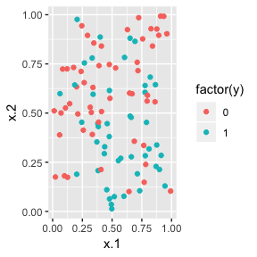

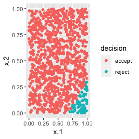

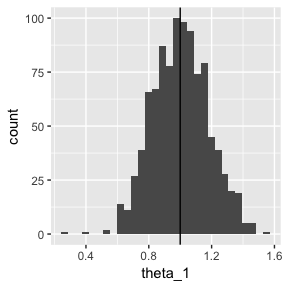

```r
data_cont_simu <- function(n,d,k) {
    set.seed(k)
    x = matrix(runif(n*d), nrow = n, ncol = d)
    theta = c(1,-1)
    log_odd = x %*% theta

    y = rbinom(n,1,1/(1+exp(-log_odd)))

    return(list(x,y))
}

library(ggplot2)

data = data_cont_simu(100,2,1)
x = data[[1]]
y = data[[2]]
df = data.frame(x = x, y = y)
ggplot(df, aes(x = x.1, y = x.2, colour = factor(y))) +
    geom_point()

data = data_cont_simu(1000,2,1)
x = data[[1]]
y = data[[2]]
df = data.frame(x = x, y = y)
hat_theta = glm(y ~ . -1, data = df, family = binomial(link = "logit"))
df$decision = factor(ifelse(predict(hat_theta, df, type="response")>0.7, "reject", "accept"))
ggplot(df, aes(x = x.1, y = x.2, colour = decision)) +
    geom_point()

theta_1 = matrix(NA, ncol = 1, nrow = 1000)
theta_2 = matrix(NA, ncol = 1, nrow = 1000)
theta_1_f = matrix(NA, ncol = 1, nrow = 1000)
theta_2_f = matrix(NA, ncol = 1, nrow = 1000)
for (k in 1:1000) {

    data = data_cont_simu(1000,2,k)
    x = data[[1]]
    y = data[[2]]
    df = data.frame(x = x, y = y)
    hat_theta = glm(y ~ . -1, data = df, family = binomial(link = "logit"))

    theta_1[k] = hat_theta$coefficients[1]
    theta_2[k] = hat_theta$coefficients[2]

    df$decision = factor(ifelse(predict(hat_theta, df, type="response")>0.6, "reject", "accept"))
    hat_theta_f = glm(y ~ . -1, data = df[df$decision == "accept",-ncol(df)], family = binomial(link = "logit"))

    theta_1_f[k] = hat_theta_f$coefficients[1]
    theta_2_f[k] = hat_theta_f$coefficients[2]
}
ggplot(data.frame(theta_1), aes(x=theta_1)) + geom_histogram() + geom_vline(xintercept = 1)
```

When the missingness mechanism is MNAR, $p(y|\boldsymbol{x},f) \neq p(y|\boldsymbol{x},nf)$ so that there is no way to ‘‘unbias’’ the resulting model without introducing data from the financing mechanism and model $p(f|\boldsymbol{x},y)$.

When the model is false, we could make use of not financed clients to estimate $p(f|\boldsymbol{x})$ and consider this as an importance function in the Importance Sampling framework. However, this gives good results when the importance function is known and under probabilistic assumptions not met in our use case. Here it must be evaluated separately and simulations show that this estimation process also introduces bias and variance and subsequently does not improve upon the financed clients’ model.

## Reject Inference methods

### Functions

The first method is Fuzzy Augmentation as described in the Appendix of [my PhD thesis](https://github.com/adimajo/manuscrit_these).

The second method is Reclassification as described in the Appendix of [my PhD thesis](https://github.com/adimajo/manuscrit_these).

The third method is Augmentation as described in the Appendix of [my PhD thesis](https://github.com/adimajo/manuscrit_these).

The fourth method is Parcelling as described in the Appendix of [my PhD thesis](https://github.com/adimajo/manuscrit_these).

The fifth method is Twins as described in the Appendix of [my PhD thesis](https://github.com/adimajo/manuscrit_these).

Each of these functions output an S4 object named ‘‘reject_infered’’. This object has slots:

- method: the Reject Inference method used;
- financed_model: the logistic regression using only financed clients’ characteristics;
- acceptance_model: the logistic regression modeling the financing decision (empty for all methods except Augmentation and Twins);
- infered_model: the logistic regression obtained using a given reject inference technique.

Call: stats::glm(formula = labels ~ ., family = stats::binomial(link = “logit”), data = df_f)

Coefficients: (Intercept) x.x.1 x.x.2  
-0.001515 1.493633 -1.570911

Degrees of Freedom: 815 Total (i.e. Null); 813 Residual Null Deviance: 1122 Residual Deviance: 1080 AIC: 1086

Call: stats::glm(formula = acc ~ ., family = stats::binomial(link = “logit”), data = df[, -which(names(df) %in% c(“labels”))])

Coefficients: (Intercept) x.x.1 x.x.2  
1754 -5037 5753

Degrees of Freedom: 999 Total (i.e. Null); 997 Residual Null Deviance: 954.8 Residual Deviance: 2.042e-05 AIC: 6

Call: stats::glm(formula = labels ~ ., family = stats::binomial(link = “logit”), data = df[, -which(names(df) %in% c(“acc”))])

Coefficients: (Intercept) x.x.1 x.x.2  
-0.001515 1.493633 -1.570911

### Methods

To efficiently use the generated S4 objects of class ‘‘reject_infered’’ several methods were implemented which we detail here.

#### print method

The print method shows the method used and the coefficients of infered_model, much like you would get from printing a object:

Call: stats::glm(formula = labels ~ ., family = stats::binomial(link = “logit”), data = df[, -which(names(df) %in% c(“acc”))])

Coefficients: (Intercept) x.x.1 x.x.2  
0.3168 2.5703 -2.7744

Degrees of Freedom: 999 Total (i.e. Null); 997 Residual Null Deviance: 1377 Residual Deviance: 1162 AIC: 1168

#### predict method

The predict method corresponds to the glm predict method for the infered model:

#### plot method

The plot method allows the modeler to compare each coefficient’s values in the financed model and the infered model.

```r
# plot(hat_theta_reclassification)
```

# Quantization

## Context

Under the term ‘‘quantization’’, we refer to the process of transforming a continuous feature into a categorical feature which values uniquely correspond to intervals of the continuous feature and to the process of regrouping values of categorical feature.

There are a few advantages to discretizing the input features:

- Interpretability: the logistic regression becomes a simple addition;
- Usability in other areas: we can address subgroups by focusing on one or several values of a given discretized feature;
- Outliers have less influence in model fitting because they are regrouped in the first (or last) value of the discretized feature;
- Non-linearity of the continuous value w.r.t. the log odd ratio: the real log odd ratio of each feature (all else equal) is considered linear in the logistic regression equation which might not be true. By discretizing each feature, we perform stepwise approximation.

There are a few drawbacks as well:

- Pre-processing task that can be costly in both human and computation time;
- Loss in predictive power if continuous model is closer to the true model;
- Harder to estimate each coefficient as there are more coefficients and subsequently less data to estimate each of them.

## Mathematical reinterpretation

### Model

We consider a random vector $\boldsymbol{X}=(X_1,X_d)$ where $X_j$ can be either continuous or qualitative (with $o_j$ distinct values). We denote by $\boldsymbol{\mathfrak{q}}=(\mathfrak{q}_1,\mathfrak{q}_d)$ the quantized random vector where $\mathfrak{q}_j$ is the quantization of $X_j$, i.e. qualitative with $m_j$ values corresponding either to unique intervals of $X_j$ (continuous case) or to unique regroupments of $X_j$’s $o_j$ values (which implies $m_j \leq o_j$).

We suppose that by quantizing features $\boldsymbol{X}$, we preserve all information about the target feature, i.e. $p(y|\boldsymbol{x},\boldsymbol{\mathfrak{q}}) = p(y|\boldsymbol{\mathfrak{q}})$.

### Hard optimization problem

Although this process seems straightforward, it is a rather complicated optimization problem in terms of combinatorics and estimation (being a discrete problem).

### Choosing the ‘‘right’’ model: which criterion?

The task is to find the optimal logistic regression $p_{\boldsymbol{\theta}}(y|\boldsymbol{\mathfrak{q}})$ where $\boldsymbol{\mathfrak{q}}$ is unknown and must be chosen in a set $\mathbf{\mathfrak{Q}}_{\boldsymbol{m}}$ very large as said in the previous section. So the model selection problem can be expressed in terms of classical criteria, e.g. AIC, BIC, where and $\mathbf{\mathfrak{Q}}_{\boldsymbol{m}}$ have to be scanned:

$$(\hat{\boldsymbol{\theta}}, \hat{\boldsymbol{\mathfrak{q}}}) = \arg \max_{(\boldsymbol{\theta},\boldsymbol{\mathfrak{q}})} \text{AIC}(p_{\boldsymbol{\theta}}(\mathbf{y}|\mathbf{\mathfrak{q}})).$$

### The need for generating ‘‘clever’’ candidates

The criterion developed in the previous part cannot be optimized directly because the set $\mathbf{\mathfrak{Q}}_{\boldsymbol{m}}$ of candidate discretizations is too large. The idea behind most existing supervised discretization method is to generate potentially ‘‘good’’ candidates (although most methods don’t depend on the predictive algorithm to be applied after discretization).

## Existing methods

### The discretization package

### Chi-2 based methods

### Entropy based methods

## Added constraints

### Few values

### Interpretability of the intervals

### Feature selection

### Automatic creation of interaction terms

## Proposed method

### General idea

1. Fitting a logistic regression between $\boldsymbol{\mathfrak{q}}$ and $y$;
2. Fitting polytomous logistic regression functions between each pair of $(x_j,\mathfrak{q}_j)$;
3. Generate new discretized features $E$ by sampling them, as $p(\mathfrak{q}_j|\mathfrak{q}_{-\{j\}},\boldsymbol{x},y) \propto p(\mathfrak{q}_j|x_j) p(y|\boldsymbol{\mathfrak{q}})$.

### Implementation

#### The glmdisc function

#### Methods associated with it

##### discretize method

The discretize method discretizes a given dataset using a previously trained discretization scheme. Its output is also a ‘‘discretization’’ object.

##### plot method

The plot method is associated with ‘‘types’’:

- ‘‘default’’: same method as plotting the resulting best method;
- ‘‘discretization’’: plots each feature’s discretization scheme;
- ‘‘all’’: produces all plots on the same frame.

# Segmentation: logistic regression trees